# pandas 进阶修炼 ｜早起Python

## 6 - 数据分组与聚合

## 加载数据

```python
import pandas as pd

df = pd.read_csv("某招聘网站数据.csv",parse_dates=['createTime'])
```

## 分组

#### Groupby 返回的是一个tuple iter。第0位是groupby的key， 第一位是值。

### 1 - 分组统计 | 多特征

```python
import numpy as np
(df[["district","salary"]]
    .groupby("district")
    .agg([np.sum, np.std,np.mean])
    .round(2))
```

| district | salary sum | salary std | salary mean |
| --- | --- | --- | --- |
| 上城区 | 52500 | 5303.30 | 26250.00 |
| 下沙 | 30000 | NaN | 30000.00 |
| ... | ... | ... | ... |
| 萧山区 | 145000 | 10307.76 | 36250.00 |
| 西湖区 | 1019500 | 7962.57 | 30893.94 |

8 rows × 3 columns

### 2 - 分组统计｜取消索引

重新按照上一题要求进行分组，但不使用 `district` 做为索引

```python
df.groupby("district", as_index=False)['salary'].mean().round(2)
```

|  | district | salary |
| --- | --- | --- |
| 0 | 上城区 | 26250.00 |
| 1 | 下沙 | 30000.00 |
| ... | ... | ... |
| 6 | 萧山区 | 36250.00 |
| 7 | 西湖区 | 30893.94 |

8 rows × 2 columns

### 3 - 分组统计｜排序

计算并提取平均薪资最高的区

```python
(df[['district','salary']]
    .groupby('district')
    .mean()
    .sort_values(by='salary',ascending=False)
    .head(1))
```

| district | salary |
| --- | --- |
| 萧山区 | 36250.0 |

### 4 - 分组统计｜频率

计算不同行政区(`district`)，不同规模公司(`companySize`)出现的次数

```python
pd.DataFrame(df.groupby(['district','companySize']).size())
```

| district | companySize | 0 |
| --- | --- | --- |
| 上城区 | 50-150人 | 2 |
| 下沙 | 150-500人 | 1 |
| ... | ... | ... |
| 西湖区 | 50-150人 | 5 |
|  | 500-2000人 | 9 |

21 rows × 1 columns

```python
(pd.DataFrame(
    df[['district','companySize']]
        .groupby(['district','companySize'])
        .value_counts()))
```

| district | companySize | 0 |
| --- | --- | --- |
| 上城区 | 50-150人 | 2 |
| 下沙 | 150-500人 | 1 |
| ... | ... | ... |
| 西湖区 | 50-150人 | 5 |
|  | 500-2000人 | 9 |

21 rows × 1 columns

```python
pd.DataFrame(df.groupby("district")['companySize'].value_counts())
```

| district | companySize | companySize |
| --- | --- | --- |
| 上城区 | 50-150人 | 2 |
| 下沙 | 150-500人 | 1 |
| ... | ... | ... |
| 西湖区 | 50-150人 | 5 |
|  | 15-50人 | 1 |

21 rows × 1 columns

### 5 - 分组统计｜修改索引名

将上一题的索引名修改为

- district -> 行政区
- companySize -> 公司规模

```python
(pd.DataFrame(
    df.groupby("district")['companySize']
    .value_counts())
         .rename_axis(["行政区", "公司规模"]))
```

| 行政区 | 公司规模 | companySize |
| --- | --- | --- |
| 上城区 | 50-150人 | 2 |
| 下沙 | 150-500人 | 1 |
| ... | ... | ... |
| 西湖区 | 50-150人 | 5 |
|  | 15-50人 | 1 |

21 rows × 1 columns

### 6 - 分组统计｜计数

计算上一题，每个区出现的公司数量

```python
df.head(5)
```

|  | positionName | companySize | ... | matchScore | famousCompany |
| --- | --- | --- | --- | --- | --- |
| 0 | 数据分析 | 50-150人 | ... | 15.101875 | False |
| 1 | 数据建模 | 150-500人 | ... | 32.559414 | False |
| 2 | 数据分析 | 2000人以上 | ... | 14.972357 | False |
| 3 | 数据分析 | 500-2000人 | ... | 12.874153 | True |
| 4 | 数据分析 | 2000人以上 | ... | 12.755375 | True |

5 rows × 19 columns

```python
df.groupby('district').size()
```

```
district
上城区     2
下沙      1
       ..
萧山区     4
西湖区    33
Length: 8, dtype: int64
```

```python
df.groupby("district")['companySize'].count()
```

```
district
上城区     2
下沙      1
       ..
萧山区     4
西湖区    33
Name: companySize, Length: 8, dtype: int64
```

### 7 - 分组查看｜全部

将数据按照 `district`、`salary` 进行分组，并查看各分组内容

```python
pd.DataFrame(df.groupby(['district','salary']).size())
```

| district | salary | 0 |
| --- | --- | --- |
| 上城区 | 22500 | 1 |
|  | 30000 | 1 |
| ... | ... | ... |
| 西湖区 | 40000 | 2 |
|  | 45000 | 2 |

50 rows × 1 columns

```python
df.groupby(["district",'salary']).groups
```

```
{('上城区', 22500): [81], ('上城区', 30000): [97], ('下沙', 30000): [31], ('余杭区', 7500): [84], ('余杭区', 20000): [52, 103], ('余杭区', 22500): [23, 51], ('余杭区', 25000): [62], ('余杭区', 27500): [24, 49], ('余杭区', 29000): [93], ('余杭区', 30000): [4, 10, 13, 18, 59, 61, 65, 68, 74, 76, 86, 92, 94], ('余杭区', 35000): [101]…
```

### 8 - 分组查看｜指定

将数据按照 `district`、`salary` 进行分组，并查看西湖区薪资为 30000 的工作

```python
df.groupby(["district",'salary']).get_group(("西湖区",30000))
```

|  | positionName | companySize | ... | matchScore | famousCompany |
| --- | --- | --- | --- | --- | --- |
| 11 | 大数据分析工程师(J11108) | 2000人以上 | ... | 4.245066 | False |
| 27 | 数据分析经理 | 2000人以上 | ... | 1.164082 | True |
| ... | ... | ... | ... | ... | ... |
| 88 | 资深数据分析师 | 500-2000人 | ... | 0.502371 | False |
| 98 | 数据分析建模工程师 | 50-150人 | ... | 0.356308 | False |

7 rows × 19 columns

### 9 - 分组规则｜通过匿名函数1

根据 createTime 列，计算每天不同 行政区 新增的岗位数量

```python
pd.DataFrame(
    df.groupby(
        df.createTime.apply(lambda x:x.day)
    )['district']
    .value_counts())
```

| createTime | district | district |
| --- | --- | --- |
| 9 | 余杭区 | 1 |
| 10 | 拱墅区 | 1 |
| ... | ... | ... |
| 16 | 上城区 | 1 |
|  | 下沙 | 1 |

21 rows × 1 columns

### 10 - 分组规则｜通过匿名函数2

计算各行政区的企业领域（industryField）包含电商的总数

```python
df['industryField'].str.contains('电商')

df.groupby('district')["industryField"].apply(
    lambda x:x.str.contains('电商').sum()
)
```

```
district
上城区    0
下沙     1
      ..
萧山区    3
西湖区    4
Name: industryField, Length: 8, dtype: int64
```

### 11 - 分组规则｜通过内置函数

通过 positionName 的长度进行分组，并计算不同长度岗位名称的薪资均值

```python
df.set_index("positionName").groupby(len)['salary'].mean().round(2)
```

```
positionName
4     30125.00
5     34083.33
        ...
21    21500.00
23    60000.00
Name: salary, Length: 18, dtype: float64
```

### 13 - 分组规则｜通过多列

计算不同 工作年限（`workYear`）和 学历（`education`）之间的薪资均值

```python
pd.DataFrame(
    df['salary']
    .groupby([df['workYear'], df['education']])
    .mean()
    .round(2))
```

| workYear | education | salary |
| --- | --- | --- |
| 1-3年 | 不限 | 36250.00 |
|  | 本科 | 31000.00 |
| ... | ... | ... |
| 应届毕业生 | 不限 | 32500.00 |
|  | 本科 | 33833.33 |

12 rows × 1 columns

```python
(df[['salary','workYear', 'education']]
    .groupby(['workYear', 'education'])
    .mean()
    .round(2))
```

| workYear | education | salary |
| --- | --- | --- |
| 1-3年 | 不限 | 36250.00 |
|  | 本科 | 31000.00 |
| ... | ... | ... |
| 应届毕业生 | 不限 | 32500.00 |
|  | 本科 | 33833.33 |

12 rows × 1 columns

### 14 - 分组转换｜ transform

在原数据框 df 新增一列，数值为该区的平均薪资水平

```python
df['mean_salary'] = df[['district','salary']].groupby('district').transform('mean')
```

transform 与 query 等用法相同，但是transform 返回与输入等长的数组，eval 与 query 返回不等长数组

### 15 - 分组过滤｜filter

提取平均工资小于 30000 的行政区的全部数据

```python
df.groupby('district').filter(lambda x: x['salary'].mean() < 30000)
```

|  | positionName | companySize | ... | 总分 | mean_salary |
| --- | --- | --- | --- | --- | --- |
| 2 | 数据分析 | 2000人以上 | ... | 94.972357 | 25250.0 |
| 3 | 数据分析 | 500-2000人 | ... | 80.874153 | 25250.0 |
| ... | ... | ... | ... | ... | ... |
| 96 | 数据分析专员 | 2000人以上 | ... | 1.460323 | 28500.0 |
| 97 | 旅游大数据分析师（杭州） | 50-150人 | ... | 1.826756 | 26250.0 |

10 rows × 21 columns

### 16 - 分组可视化

对杭州市各区公司数量进行分组，并使用柱状图进行可视化

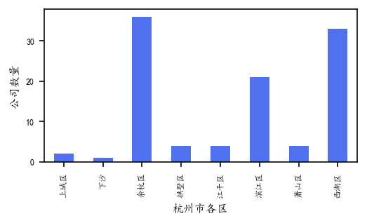

```python
import matplotlib.pyplot as plt
%config InlineBackend.figure_format = 'retina'
plt.rcParams['font.sans-serif'] = ['KaiTi', 'SimHei', 'FangSong']  # 汉字字体,优先使用楷体，如果找不到楷体，则使用黑体


df.groupby("district")['positionName'].count().plot(
    kind='bar', figsize=(4, 2), color='#5172F0', fontsize=6)

plt.ylabel("公司数量",fontsize = 8)
plt.xlabel("杭州市各区",fontsize = 8)

plt.show()
```

## 聚合

### 17 - 聚合统计

分组计算不同行政区，薪水的最小值、最大值和平均值

```python
df.groupby('district')['salary'].agg([min, max, np.mean]).round(2)
```

| district | min | max | mean |
| --- | --- | --- | --- |
| 上城区 | 22500 | 30000 | 26250.00 |
| 下沙 | 30000 | 30000 | 30000.00 |
| 余杭区 | 7500 | 60000 | 33583.33 |
| 拱墅区 | 24000 | 30000 | 28500.00 |
| 江干区 | 3500 | 45000 | 25250.00 |
| 滨江区 | 7500 | 50000 | 31428.57 |
| 萧山区 | 25000 | 45000 | 36250.00 |
| 西湖区 | 6500 | 45000 | 30893.94 |

### 18 - 聚合统计｜修改列名

将上一题的列名（包括索引名）修改为中文

```python
df.groupby('district').agg(最低工资=('salary', 'min'), 最高工资=(
    'salary', 'max'), 平均工资=('salary', 'mean')).rename_axis(["行政区"])
```

| 行政区 | 最低工资 | 最高工资 | 平均工资 |
| --- | --- | --- | --- |
| 上城区 | 22500 | 30000 | 26250.000000 |
| 下沙 | 30000 | 30000 | 30000.000000 |
| 余杭区 | 7500 | 60000 | 33583.333333 |
| 拱墅区 | 24000 | 30000 | 28500.000000 |
| 江干区 | 3500 | 45000 | 25250.000000 |
| 滨江区 | 7500 | 50000 | 31428.571429 |
| 萧山区 | 25000 | 45000 | 36250.000000 |
| 西湖区 | 6500 | 45000 | 30893.939394 |

### 19 - 聚合统计｜组合

对不同岗位(`positionName`)进行分组，并统计其薪水(`salary`)中位数和得分(`score`)均值

```python
df.groupby('positionName').agg({'salary': np.median, 'score': np.mean})
```

| positionName | salary | score |
| --- | --- | --- |
| BI数据分析师 | 20000.0 | 2.666667 |
| bi数据分析师 | 40000.0 | 5.000000 |
| 业务与数据分析师 | 30000.0 | 3.000000 |
| 产品经理/数据分析（核心业务）-2020届春招 | 60000.0 | 3.000000 |
| 产品运营（偏数据分析） | 27500.0 | 15.000000 |
| ... | ... | ... |
| 金融数据分析师 | 22500.0 | 5.000000 |
| 银行数据分析岗 | 50000.0 | 5.000000 |
| 高级数据分析专员 | 22500.0 | 4.000000 |
| 高级数据分析师 | 30000.0 | 3.666667 |
| 高级财务数据分析师 | 28750.0 | 4.500000 |

55 rows × 2 columns

### 20 -聚合统计｜多层

```python
df.groupby('district').agg(
    {'salary': [np.mean, np.median, np.std], 'score': np.mean}
).round(2)
```

| district | salary mean | salary median | salary std | score mean |
| --- | --- | --- | --- | --- |
| 上城区 | 26250.00 | 26250.0 | 5303.30 | 2.00 |
| 下沙 | 30000.00 | 30000.0 | NaN | 6.00 |
| 余杭区 | 33583.33 | 30000.0 | 10857.85 | 15.17 |
| 拱墅区 | 28500.00 | 30000.0 | 3000.00 | 2.75 |
| 江干区 | 25250.00 | 26250.0 | 17255.43 | 39.25 |
| 滨江区 | 31428.57 | 30000.0 | 10445.44 | 12.95 |
| 萧山区 | 36250.00 | 37500.0 | 10307.76 | 18.25 |
| 西湖区 | 30893.94 | 30000.0 | 7962.57 | 8.06 |

### 21 - 聚合统计｜自定义函数

在 18 题基础上，在聚合计算时新增一列计算最大值与平均值的差值

```python
def myfunc(x):
    return x.max()-x.mean()

df.groupby('district').agg(
    最低工资=('salary', 'min'),
    最高工资=('salary', 'max'),
    平均工资=('salary', 'mean'),
    最大值与均值差值=('salary', myfunc)).rename_axis(["行政区"])
```

| 行政区 | 最低工资 | 最高工资 | 平均工资 | 最大值与均值差值 |
| --- | --- | --- | --- | --- |
| 上城区 | 22500 | 30000 | 26250.000000 | 3750.000000 |
| 下沙 | 30000 | 30000 | 30000.000000 | 0.000000 |
| 余杭区 | 7500 | 60000 | 33583.333333 | 26416.666667 |
| 拱墅区 | 24000 | 30000 | 28500.000000 | 1500.000000 |
| 江干区 | 3500 | 45000 | 25250.000000 | 19750.000000 |
| 滨江区 | 7500 | 50000 | 31428.571429 | 18571.428571 |
| 萧山区 | 25000 | 45000 | 36250.000000 | 8750.000000 |
| 西湖区 | 6500 | 45000 | 30893.939394 | 14106.060606 |